# 2-2. Bayesian Statistics

Sau-Chin Chen

2016年10月18日

*Most information in this exercise comes Simon Jackman’s book ‘Bayesian Analysis for the Social Sciences’, Alex Etz’s blog post on [updating priors via the likelihood](https://alexanderetz.com/2015/07/25/understanding-bayes-updating-priors-via-the-likelihood/), and Jim Granges’ blog post on [(pesky?) priors](https://jimgrange.wordpress.com/2016/01/18/pesky-priors/).*

When we do research, we often start with a prior belief that a hypothesis is true. Then, we collect data, and we use this data to update our belief that a theory is true. Bayesian statistics allows you to update prior beliefs into posterior probabilities in a logically consistent manner. Before we have collected data, the **prior odds** of Hypothesis 1 (H1) over the null-hypothesis (H0) are P(H1)/P(H0), After we have collected data, we have the **posterior odds** P(H1|D)/P(H0|D), which you can read as the probability of H1, given the data, divided by the probability of H0, given the data. There are different approaches to Bayesian statistics. In this assignment we will first discuss Bayes factors, and then Bayesian estimation.

### Bayes factor

The ratio of the prior odds and the posterior odds is the **Bayes factor**. In other words, the Bayes factor represents how much we have updated our beliefs, based on observing the data. We can express Bayes factors to indicate how much more likely H1 is given the data compared to H0 (often indicated by $B_{10}$ ) or as how much more likely H0 is compared to H1 ($B_{01}$), and $B_{10}$ = 1/$B_{01}$. Similar to likelihoods (and formally called a **marginal likelihood**, or a weighted average likelihood ratio), a Bayes factor of 1 did not change our beliefs (the posterior odds are exactly the same as our prior odds). A very large Bayes factor of H1 over H0 has increased our belief in H1, and a Bayes Factor close to 0 has increased our belief in H0. The contribution of the Bayes Factor and the prior in calculating the posterior odds is clear in the following formula:
$$\frac{P(H1|D)}{P(H0|D)} = \frac{P(D|H1)}{P(D|H0)} \times \frac{P(H1)}{P(H0)}$$
*Posterior Probability = Likelihood Ratio $\times$ Prior Probability*

A Bayesian analysis of data requires specifying the prior. Here, we will continue our example based on a binomial probability, such as a coin flip. In the likelihood example, we compared two point hypotheses (e.g., $\theta$ = 0.5 vs. $\theta$ = 0.8). In Bayesian statistics, parameters are considered to be random variables, and the uncertainty or degree of belief with respect to the parameters is quantified by **probability distributions**.

A binomial probability lies between 0 and 1. You could draw any probability density you want over 0 and 1, and turn it into a prior, but for good reasons (simplicity, mostly) a beta-prior is often used for binomial probabilities. The shape of the beta-prior depends on two parameters, $\alpha$ and $\beta$. Note that these are the same Greek letters as used for the Type 1 error rate and Type 2 error rate, but that is purely coincidental! The $\alpha$ and $\beta$ in binomial probabilities are unrelated to error rates, and the use of the same letters is mainly due to a lack of creativity among statisticians and the limited choice the alphabet gives us. It also does not help that $\beta$ is one of the parameters of the Beta distribution. Try to keep these different Beta’s apart! The probability density function is:

$$\int (\chi, \alpha, \beta) = \frac{1}{B(\alpha,\beta)} \chi^{\alpha - 1} (1 - \chi)^{\beta - 1}$$

where $B(\alpha,\beta)$ is the beta function. Understanding the mathematical basis of this function is beyond the scope of this assignment, but you can read more on [Wikipedia](https://en.wikipedia.org/wiki/Beta_distribution) or in [John Kruschke’s book](https://sites.google.com/site/doingbayesiandataanalysis/) if interested. The beta-prior for a variety of values for $\alpha$ and $\beta$ can be seen in the figure below.

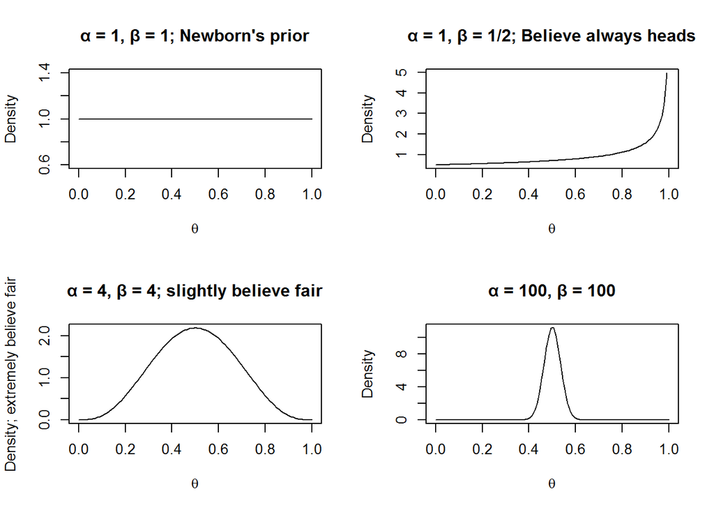

Let’s assume the newborn baby, the true believer, the slightly skeptic and the extreme skeptic all buy the coin, flip it n = 20 times, and observe x = 10 heads. This outcome can be plotted as a binomial distribution with 10 heads out of 20 trials, or as a Beta(11, 11) distribution.

The newborn baby had a prior Beta distribution with α = 1 and β = 1, which equals a binomial likelihood distribution for 0 heads out of 0 trials. The posterior is a Beta distribution with Beta($\alpha^*, \beta^*$), where:

$$\alpha^* = \alpha + x = 1 + 10 = 11$$
$$\beta^* = \beta + n – x = 1 + 20 – 10 = 11$$

Or calculating these values more directly from the α and β of the prior and likelihood:
$$\alpha^* = \alpha_{prior} + \alpha_{likelihood} – 1 = 1 + 11 - 1= 11$$
$$\beta^* = \beta_{prior} + \beta_{likelihood} – 1 = 1 + 11 - 1= 11$$